# DA_Project

Author

Alex Copeland

## Introduction

In this study, we will be assessing multiple questions about how booking characteristics affect hotel average daily rate (ADR) and hotel booking patterns. This is important because hotels use patterns similar to this study to define their average daily rate to maximize profits and help improve the guests experience staying at the hotel. We will be using statistical methods such as t-tests and linear regression models to determine any statistically significant relationship between adr and the other characteristics. The following research questions will be used in this study.

1. Do city hotels or resort hotels have more children per booking?
2. Which combinations of characteristics affect adr the most?
3. Do repeated guest stay longer than first time guest?
4. Is average daily rate lower for longer stays?

## Dataset

The dataset used for this project comes from the TidyTuesday GitHub repository and contains information about hotel bookings for city and resort hotels. Each observation in the dataset is a unique booking at either type of hotel with multiple variables describing the booking.

Key variables used in this study

- adr - Average Daily Rate (price per day)
- adults, children, babies - Number of guests in the booking
- lead_time - Number of days between booking and arrival
- stays_in_week_nights and stays_in_weekend_nights - Length of stay broken into subsets by weekday and weekend nights.
- arrival_date_month - Current month at time of booking
- is_repeated_guest - Is guest repeated or not (0 = no, 1 = yes)

The dataset is separated into subsets for city hotels and resort hotels. This allows for comparison by type of hotel. Similarly, the dataset was separated into two subsets for first time guest and repeated guest for comparison by type of guest. Additionally, a new variable total_days_stayed was created to answer question three.

## Methods

There was no cleaning necessary for the dataset, for our statistical analyses, there were only four observations that we decided to throw away and not use. For the data manipulation, we created subsets of the dataset that contained the observations of only bookings for city hotels and resort hotels for research question one. Also, we again subset the data into first time guest bookings and repeated guest bookings for the analysis of question three.

## Analysis

#### Research Question One

- Do city hotels or resort hotels have more children per booking?

An independent-samples t test was conducted to compare number of children per booking between city hotels and resort hotels. Participants in city hotels had a mean number of children per booking of $M = 0.091 (0.37)$, whereas participants in resort hotels had a mean of $M = 0.129 (0.45)$. This difference was statistically significant, $t(68986) = -12.422$, $p < .0001$. These results indicate that resort hotels have more children per booking than city hotels. While there is still a statistically significant difference, the difference is small with only $0.04$ more children per booking for resort hotels. This implies that resort hotels are more likely to have bookings with children. Assuming that each booking only includes one child, then only 9.1% of bookings have one child for city hotels and only 12.9% of bookings for resort hotels have one child. This also tells us that the majority of hotel bookings do not include any children in the first place.

Average Number of Children per Hotel Type

[figure not shown]

#### Research Question Two

- Which combinations of characteristics affect adr the most?

This table shows the results of the three regression models for predicting the average daily rate using booking characteristics across overall, city hotel, and resort hotel, and the graph represents the coefficient estimates and the 95% confidence intervals for each characteristic.

Regression Output Table

| Predictors | Overall | City Hotel City | Resort Hotel Resort |
| --- | --- | --- | --- |
| (Intercept) | 62.172*** | 62.527*** | 54.287*** |
|  | (0.474) | (0.558) | (0.852) |
| adults | 19.806*** | 24.028*** | 15.040*** |
|  | (0.234) | (0.277) | (0.407) |
| children | 39.612*** | 35.659*** | 46.741*** |
|  | (0.337) | (0.375) | (0.631) |
| babies | 7.715*** |  | 21.147*** |
|  | (1.375) |  | (2.353) |
| lead_time | -0.040*** | -0.061*** | -0.022*** |
|  | (0.001) | (0.001) | (0.003) |
| stays_in_week_nights | 1.170*** | 0.953*** | 2.279*** |
|  | (0.071) | (0.098) | (0.168) |
| stays_in_weekend_nights |  | -0.404* | 0.975** |
|  |  | (0.162) | (0.351) |
| R2 | 0.163 | 0.192 | 0.169 |

+ p < 0.1, * p < 0.05, ** p < 0.01, *** p < 0.001

Reading the regression output table, we can see that per the highest adjusted $R^2$, the babies predictor was not included in the city hotel model, and the amount of weekend nights were not included in the overall model. One conclusion that we can make is that babies have a stronger relationship with average daily rate in just resort hotels. Also, the amount of weekend nights booked for the overall model was not included, which was not expected. This variable did not contribute enough to improve the adjusted $R^2$ to be included in the analysis.

Coefficient Estimates and 95% Confidence Intervals

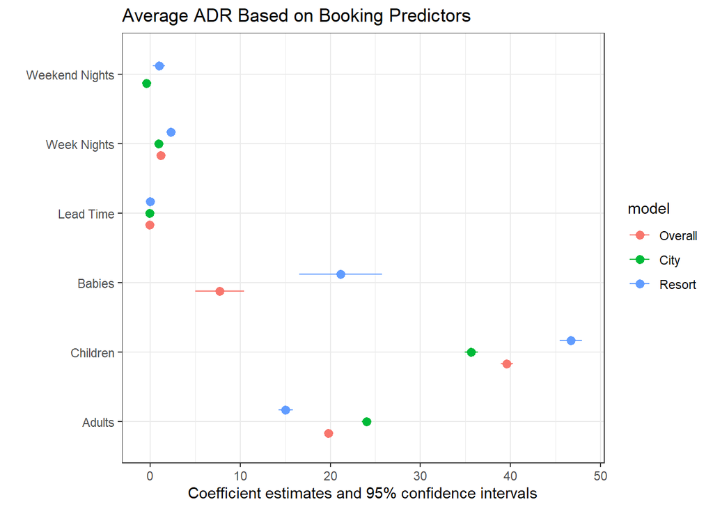

#### Research Question Three

- Do repeated guest stay longer than first time guest?

An independent-samples t test was conducted to compare mean total nights stayed between first time guest and and returning guests. Participants in first time guest had a mean total nights stayed of $M = 3.48 (SD = 2.55)$, whereas returning guests had a mean of $M = 1.93 (SD = 2.14)$. This difference was statistically significant, $t(4174.2) = 43.69$, $p < .0001$. These results indicate that first time guest stay significantly longer on average than repeated guests. First time guests stay on average 1.55 nights longer than repeated guests.

Average Days Stayed by Type of Guest

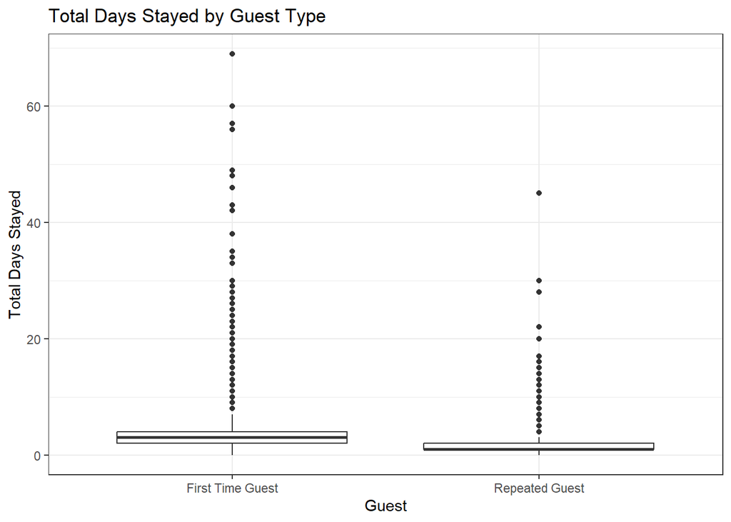

Similarly to the first graph, the mean total days stayed for each group are relatively small, but we can clearly see a difference here with first time guest being larger than repeated guests. Also, the outliers for first time guests consistently are higher outliers than repeated guests. The most days stayed for first time guest is 69 days, and the most days stayed for repeated guest is 45 days.

#### Research Question Four

- Is average daily rate lower for longer stays?

A linear regression analysis was conducted to examine whether average daily rate was associated with total days stayed. The overall regression model was statistically significant, $F([1, 119,388) = 553.7$, $p <0.0001$, and explained 0.46% of the variance in average daily rate ($R^2 = 0.004617$). Total days stayed was a significant predictor of average daily rate $(\beta = 1.34, p < 0.0001)$. These results indicate that each additional day stayed adds about $1.34 to the average daily rate. While very minimal, longer stays has a significant relationship to average daily rate.

Best Fit Line for ADR Based on Total Days Stayed

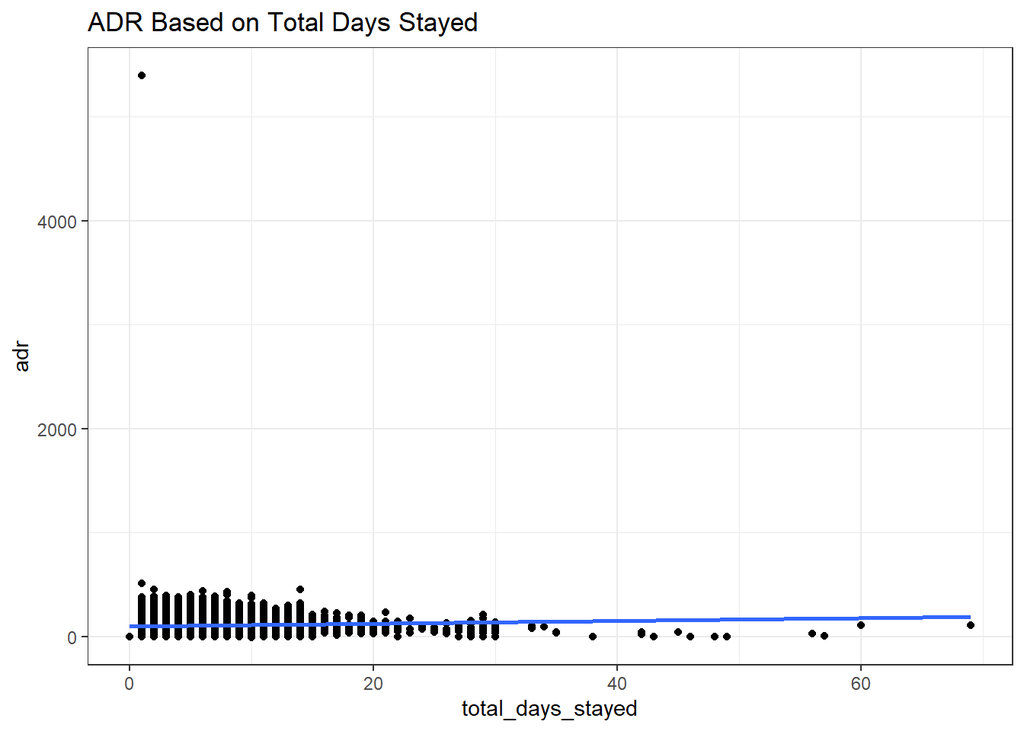

At first this plot looks odd, but note that since the x axis are in terms of days, each observation falls on a whole number, causing the stacking of observations and breaks in between them in the plot.

Regression Output Table

|  | (1) |
| --- | --- |
| (Intercept) | 97.229*** |
|  | (0.244) |
| total_days_stayed | 1.343*** |
|  | (0.057) |
| R2 | 0.005 |

+ p < 0.1, * p < 0.05, ** p < 0.01, *** p < 0.001

## Conclusion

This study examined how booking characteristics relate to average daily rate and booking behaviors. For the first analysis, we concluded that resort hotels have slightly more children per booking. Surprisingly resort hotels only had an average of 0.04 more children per booking. We assumed that resort hotels would have a noticeable amount more children per booking, considering resort hotels are normally destination places families travel to for trips. As mentioned earlier, city hotels have only 9.1% of bookings with children and resorts have only 12.9% of bookings with children. Although it is significant, the practical use of this would be very minimal.

For the third analysis, a t-test was ran to test if on average repeated guest stay longer than first time guest. On average first time guest stayed 3.48 total days where returning guest stayed 1.93 total days. On average first time guest stay 1.55 days longer than repeated guests. This suggest that first time guest book longer trips, whereas returning guest book slightly shorter trips. Practically this makes sense as well, a returning guest may only want to return for a weekend, where their first trip was an entire week.

For the fourth analysis, a linear regression model was ran to see if longer stays affected average daily rate. We found that on average each additional day added $1.34 to the average daily rate. Overall, this does suggest that there is a signification relationship between total days stayed and average daily rate, but with each day only adding $1.34 this affects average daily rate very minimally. This was very surprising to me as we assumed that the longer you stayed the less the average daily rate would be.

Originally wanted to answer what could predict if a guest would be a returning guest, but after researching, I feel like that is out of scope of this class. For future works on this study, I would like to come up with some analysis that would give insight on why a guest returns to a hotel.